# Final Presentation

Bryant

2022-12-03

# Email Classification

## Question/Problem

This project started off with creating a good email spam classification filter. Gmail’s spam classification model works well on a general setting. However I would like something more customized to my needs. I want to include in my model all of my emails that are not necessarily “spam” but that I still delete immediately (i.e. facebook notifications) or never bother to open.

I then had the question of whether part of speech in each subject line will correlate to with spam or not spam (“ham”) emails.

I will evaluate whether there is evidence to reject the null hypothesis that part of speech usage does not differ in the subjects of emails that I read and emails that I leave unopened.

Finally, I will attempt to build a classification model that can accurately predict my behavior whether or not I will open an email to read it. I will test different classification models, parameters, and features to see which combination will perform the best.

## Data

I will use my own emails from the past 2 years as my data to evaluate Part of Speech correlation and train and test my model.

I used takeout.google.com to download a .mbox file of all my “Opened” emails, and “Unread” emails.

- Opened: 4,478
- Unread: 12,913
- Total: 17,391

I then had to convert emails to .txt files (this took a very long time).

I then had to clean my data:

- I got rid of attachments, images etc.
- I normalized text (made it lowercase, got rid of weird characters, etc)
- I then used regex expressions to extract my main features: Sender, subject, Reply-To, Content of email

```python
def find_features(file_utf8, label='spam'):

    with open(file_utf8, 'r', encoding='utf-8', errors='ignore') as f:
        data = f.read()

        # Convert to bytes to replace some stuff we don't want then decode back to string
        data = data.encode('utf-8').replace(b"\xc2\xa0", b"") # Nonbreaking space
        data = data.replace(b"\xa0", b"") # A weird A symbol
        data = data.decode('utf-8', errors='ignore')

        email_list = re.split(r"From:\t|From: ", data)
        print(len(email_list))

    from_ = re.compile(r'(.*)\n')
    subject_ = re.compile(r'Subject:\s(.*)\n')
    content_ = re.compile(r'\n\n([\s\S]*)')
    reply_to_ = re.compile(r'Reply-To:\s(.*)\n')

    email_dict = []
    for i,email in enumerate(email_list):
        from_feature = re.search(from_, email)
        subject_feature = re.search(subject_, email)
        content_feature = re.search(content_, email[:400])
        reply_to_feature = re.search(reply_to_, email)

        if subject_feature is None:
            subject = "None"
        else:
            subject = subject_feature.groups()[0]

        if content_feature is None:
            content = "None"
        else:
            content = content_feature.groups()[0]

        if reply_to_feature is None:
            reply_to = "None"
        else:
            reply_to = reply_to_feature.groups()[0]

        email_dict.append({"Label": label,
                           "From": from_feature.groups()[0],
                           "Subject": subject,
                           "Reply To": reply_to,
                           "Content": content})

    return email_dict


def append_to_csv(email_dict, header=False):
    csv_columns = ["Label", "From", "Subject", "Reply To", "Content"]
    csv_file = "spam_ham.csv"
    with open(csv_file, 'a', encoding='utf-8', errors='ignore') as csvfile:
        writer = csv.DictWriter(csvfile, fieldnames=csv_columns, lineterminator='\n')
        if header:
            writer.writeheader()
        for i,data in enumerate(email_dict):
            writer.writerow(data)

    pass


def create_csv():

    unread_files = ["unread.txt", "unread2.txt", "unread3.txt", "unread4.txt", "unread5.txt", "unread6.txt",
                    "unread7.txt", "unread8.txt", "unread9.txt", "unread10.txt"]
    i = 0
    for file in unread_files:
        email_dict = find_features(file, label='spam')
        if i == 0:
            append_to_csv(email_dict, header=True)
        else:
            append_to_csv(email_dict)
        i += 1
    print("Finished unread")
    read_files = ["opened.txt", "opened2.txt", "opened3.txt", "opened4.txt", "opened5.txt", "opened6.txt"]
    for file in read_files:
        email_dict = find_features(file, label='ham')
        append_to_csv(email_dict)

        # df = pd.DataFrame(email_dict)
        # # df.replace(to_replace=[r"\\t|\\n|\\r", "\t|\n|\r"], value=["", ""], regex=True, inplace=True)
        # df.to_csv("spam_ham.csv")

    pass
```

- Finally I used spacy to find and count part of speech occurances in the subject, and first bit of the content and frequency for each email.

```python
def get_pos2():
    df = pd.read_csv("spam_ham.csv")
    # Subject And Content
    X1 = df.loc[:, 'Subject']
    X2 = df.loc[:, "Content"]

    """
    Change the tag in subject and run on POS
    """
    nlp = spacy.load("en_core_web_lg")

    added_dict = []
    for subject, content in zip(X1,X2):

        subj = nlp(subject)
        cont = nlp(str(content))

        subj_pos = np.array([token.pos_ for token in subj])
        cont_pos = np.array([token.pos_ for token in cont])
        s = len(subj_pos)
        c = len(cont_pos)

        # Adjectives
        num_subj_adjs = np.count_nonzero(subj_pos == "ADJ") if s != 0 else 0
        perc_subj_adjs = num_subj_adjs/s if s != 0 else 0
        num_cont_adjs = np.count_nonzero(cont_pos == "ADJ") if c != 0 else 0
        perc_cont_adjs = num_cont_adjs/c if c != 0 else 0
        num_total_adjs = num_subj_adjs + num_cont_adjs if s+c != 0 else 0
        perc_total_adjs = num_total_adjs/(s+c) if s+c != 0 else 0

        # Adverbs
        num_subj_advs = np.count_nonzero(subj_pos == "ADV") if s != 0 else 0
        perc_subj_advs = num_subj_advs / s if s != 0 else 0
        num_cont_advs = np.count_nonzero(cont_pos == "ADV") if c != 0 else 0
        perc_cont_advs = num_cont_advs / c if c != 0 else 0
        num_total_advs = num_subj_advs + num_cont_advs if s+c != 0 else 0
        perc_total_advs = num_total_advs / (s + c) if s+c != 0 else 0

        # Nouns
        num_subj_noun = np.count_nonzero(subj_pos == "NOUN") if s != 0 else 0
        perc_subj_noun = num_subj_noun / s if s != 0 else 0
        num_cont_noun = np.count_nonzero(cont_pos == "NOUN") if c != 0 else 0
        perc_cont_noun = num_cont_noun / c if c != 0 else 0
        num_total_noun = num_subj_noun + num_cont_noun if s+c != 0 else 0
        perc_total_noun = num_total_noun / (s + c) if s+c != 0 else 0

        # Numbers
        num_subj_num = np.count_nonzero(subj_pos == "NUM") if s != 0 else 0
        perc_subj_num = num_subj_num / s if s != 0 else 0
        num_cont_num = np.count_nonzero(cont_pos == "NUM") if c != 0 else 0
        perc_cont_num = num_cont_num / c if c != 0 else 0
        num_total_num = num_subj_num + num_cont_num if s+c != 0 else 0
        perc_total_num = num_total_num / (s + c) if s+c != 0 else 0

        # Proper Nouns
        num_subj_propn = np.count_nonzero(subj_pos == "PROPN") if s != 0 else 0
        perc_subj_propn = num_subj_propn / s if s != 0 else 0
        num_cont_propn = np.count_nonzero(cont_pos == "PROPN") if c != 0 else 0
        perc_cont_propn = num_cont_propn / c if c != 0 else 0
        num_total_propn = num_subj_propn + num_cont_propn if s+c != 0 else 0
        perc_total_propn = num_total_propn / (s + c) if s+c != 0 else 0

        # Symbols
        num_subj_sym = np.count_nonzero(subj_pos == "SYM") if s != 0 else 0
        perc_subj_sym = num_subj_sym / s if s != 0 else 0
        num_cont_sym = np.count_nonzero(cont_pos == "SYM") if c != 0 else 0
        perc_cont_sym = num_cont_sym / c if c != 0 else 0
        num_total_sym = num_subj_sym + num_cont_sym if s+c != 0 else 0
        perc_total_sym = num_total_sym / (s + c) if s+c != 0 else 0

        # Verbs
        num_subj_verb = np.count_nonzero(subj_pos == "VERB") if s != 0 else 0
        perc_subj_verb = num_subj_verb / s if s != 0 else 0
        num_cont_verb = np.count_nonzero(cont_pos == "VERB") if c != 0 else 0
        perc_cont_verb = num_cont_verb / c if c != 0 else 0
        num_total_verb = num_subj_verb + num_cont_verb if s+c != 0 else 0
        perc_total_verb = num_total_verb / (s + c) if s+c != 0 else 0

        # Interjections
        num_subj_intj = np.count_nonzero(subj_pos == "INTJ") if s != 0 else 0
        perc_subj_intj = num_subj_intj / s if s != 0 else 0
        num_cont_intj = np.count_nonzero(cont_pos == "INTJ") if c != 0 else 0
        perc_cont_intj = num_cont_intj / c if c != 0 else 0
        num_total_intj = num_subj_intj + num_cont_intj if s+c != 0 else 0
        perc_total_intj = num_total_intj / (s + c) if s+c != 0 else 0

        # Add to data frame
        added_dict.append({# Adjectives
                            "num_subj_adjs": num_subj_adjs,
                           "perc_subj_adjs": perc_subj_adjs,
                           "num_cont_adjs": num_cont_adjs,
                           "perc_cont_adjs": perc_cont_adjs,
                           "num_total_adjs": num_total_adjs,
                           "perc_total_adjs": perc_total_adjs,

                            # Adverbs
                           "num_subj_advs": num_subj_advs,
                            "perc_subj_advs": perc_subj_advs,
                            "num_cont_advs": num_cont_advs,
                            "perc_cont_advs": perc_cont_advs,
                            "num_total_advs": num_total_advs,
                            "perc_total_advs": perc_total_advs,

                           # Nouns
                           "num_subj_noun" : num_subj_noun,
                            "perc_subj_noun": perc_subj_noun,
                            "num_cont_noun": num_cont_noun,
                            "perc_cont_noun": perc_cont_noun,
                            "num_total_noun": num_total_noun,
                            "perc_total_noun": perc_total_noun,

                            # Numbers
                            "num_subj_num": num_subj_num,
                            "perc_subj_num": perc_subj_num,
                            "num_cont_num": num_cont_num,
                            "perc_cont_num": perc_cont_num,
                            "num_total_num": num_total_num,
                            "perc_total_num": perc_total_num,

                            # Proper Nouns
                            "num_subj_propn": num_subj_propn,
                            "perc_subj_propn": perc_subj_propn,
                            "num_cont_propn": num_cont_propn,
                            "perc_cont_propn": perc_cont_propn,
                            "num_total_propn": num_total_propn,
                            "perc_total_propn": perc_total_propn,

                            # Symbols
                            "num_subj_sym": num_subj_sym,
                            "perc_subj_sym": perc_subj_sym,
                            "num_cont_sym": num_cont_sym,
                            "perc_cont_sym": perc_cont_sym,
                            "num_total_sym": num_total_sym,
                            "perc_total_sym": perc_total_sym,

                            # Verbs
                            "num_subj_verb": num_subj_verb,
                            "perc_subj_verb": perc_subj_verb,
                            "num_cont_verb": num_cont_verb,
                            "perc_cont_verb": perc_cont_verb,
                            "num_total_verb": num_total_verb,
                            "perc_total_verb": perc_total_verb,

                            # Interjections
                            "num_subj_intj": num_subj_intj,
                            "perc_subj_intj": perc_subj_intj,
                            "num_cont_intj": num_cont_intj,
                            "perc_cont_intj": perc_cont_intj,
                            "num_total_intj": num_total_intj,
                            "perc_total_intj": perc_total_intj
                             })

    subject = pd.DataFrame(added_dict)
    subject.to_csv("new_cols.csv", header=True)

    pass
```

## Variables

In case you didn’t catch it my Dependent (Response) Variable is Opened or Unread email labeled either as Spam or 0 for Unread and ham or 1 as Opened.

My Independent (Predictor) Variables are still to be determined but currently they are:

- From
- Subject
- Reply-To
- Content (Just the first couple lines)
- Subject PoS:
  - Adjectives, Adverbs, Nouns, Proper Nouns, Numbers, Symbols, Verbs, and Interjections

## Visualization for PoS

```r
# Load tidyverse and my Data
library(tidyverse)
data <- read_csv("spam_ham.csv") %>%
  mutate(Label = ifelse(Label == "spam", 0,1))
# Crazy Pivot Longer and wider
new_data = data %>% pivot_longer(cols = num_subj_adjs:perc_total_intj,
                      names_to = "variables",
                      values_to = "values") %>%
  separate(variables, c("count_freq", "subject_content_total", "pos")) %>%
  pivot_wider(names_from = c("count_freq", "subject_content_total"),
              values_from = "values")
```

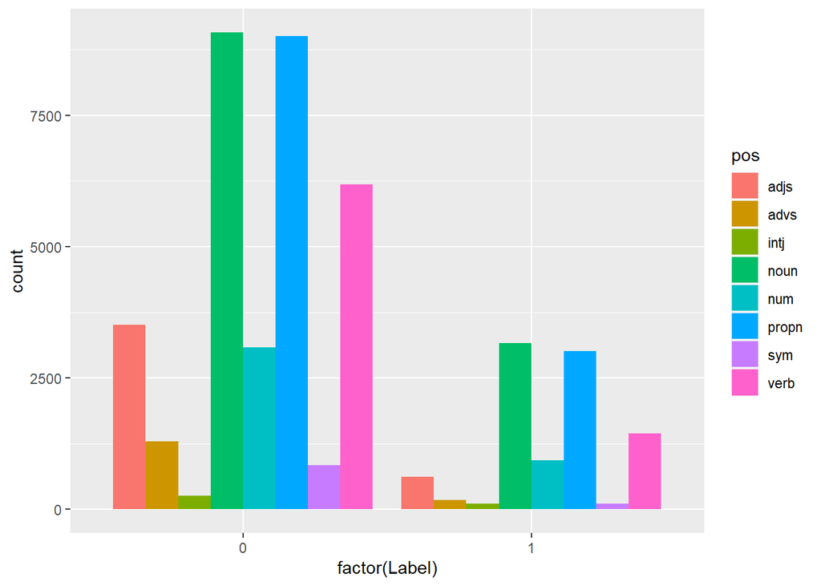

```r
# Plots
plot = new_data %>% filter(num_subj>0, perc_subj>0, num_cont>0, perc_cont>0, num_total>0, perc_total>0) %>%
  ggplot(aes(factor(Label), fill = pos)) +
  geom_bar(position=position_dodge())
plot
```

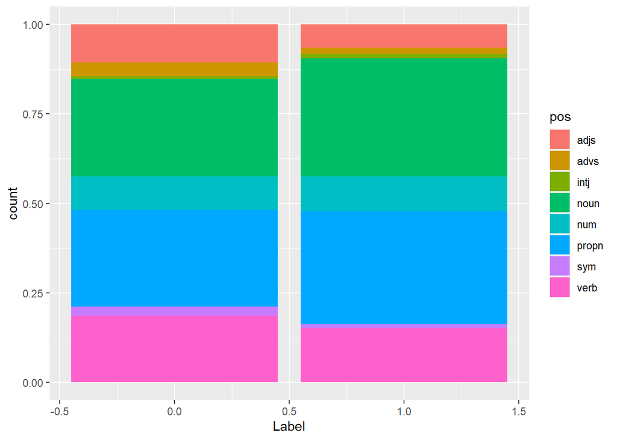

```r
plot = new_data %>% filter(num_subj>0, perc_subj>0, num_cont>0, perc_cont>0, num_total>0, perc_total>0) %>%
  ggplot(aes(Label, fill = pos)) +
  geom_bar(position=position_fill())
plot
```

## Chi-squared test

```r
means = new_data %>%
  group_by(pos,Label) %>%
  summarise(n = n(),
            total_mean = mean(num_total),
            total_mean_perc = mean(perc_total),
            sd = sd(num_total),
            subj_mean = mean(num_subj),
            subj_mean_perc = mean(perc_subj))
```

[output not shown]

```r
print(means)
```

```
## # A tibble: 16 × 8
## # Groups:   pos [8]
##    pos   Label     n total_mean total_mean_perc    sd subj_mean subj_mean_perc
##    <chr> <dbl> <int>      <dbl>           <dbl> <dbl>     <dbl>          <dbl>
##  1 adjs      0 12925      1.69          0.0389  1.66     0.365         0.0438
##  2 adjs      1  4483      1.46          0.0324  1.49     0.218         0.0266
##  3 advs      0 12925      0.877         0.0178  1.20     0.155         0.0168
##  4 advs      1  4483      1.01          0.0204  1.27     0.0718        0.00759
##  5 intj      0 12925      0.231         0.00461 0.512    0.0299        0.00480
##  6 intj      1  4483      0.463         0.00960 0.692    0.0328        0.00533
##  7 noun      0 12925      6.23          0.141   3.40     1.33          0.166
##  8 noun      1  4483      6.34          0.152   3.30     1.37          0.201
##  9 num       0 12925      2.08          0.0453  2.22     0.479         0.0511
## 10 num       1  4483      2.04          0.0434  2.33     0.563         0.0552
## 11 propn     0 12925     10.1           0.240   7.30     2.70          0.303
## 12 propn     1  4483      7.88          0.181   5.52     2.51          0.315
## 13 sym       0 12925      0.375         0.00757 0.847    0.109         0.0116
## 14 sym       1  4483      0.261         0.00535 0.687    0.0723        0.00704
## 15 verb      0 12925      3.52          0.0747  2.61     0.655         0.0806
## 16 verb      1  4483      3.94          0.0840  2.55     0.437         0.0587
```

```r
#write_csv(means,"means.csv")
```

I need to run a chisquared test to see if there is even a significant difference between the distributions of each part of speech on my spam emails and ham emails.

```python
from scipy import stats
import pandas as pd
import numpy as np

def chisquared():
    """Get my chisquared test"""

    # Load my Data
    df = pd.read_csv("means.csv")

    # Get my arrays to pass into chisquared test
    spam_means = df[df["Label"]==0]["total_mean"]
    ham_means = df[df["Label"]==1]["total_mean"]

    spam_mean_perc = df[df["Label"] == 0]["total_mean_perc"]
    ham_mean_perc = df[df["Label"] == 1]["total_mean_perc"]

    spam_subj_mean = df[df["Label"]==0]["subj_mean"]
    ham_subj_mean = df[df["Label"]==1]["subj_mean"]
    spam_subj_perc = df[df["Label"]==0]["subj_mean_perc"]
    ham_subj_perc = df[df["Label"]==1]["subj_mean_perc"]

    means = np.array([spam_means, ham_means])

    # Run chisquare test
    stat, p, dof, ex = stats.chi2_contingency(means.T)
    print("contigency p for total mean counts: ", p)
    stat, p, dof, ex = stats.chi2_contingency(np.array([spam_mean_perc, ham_mean_perc]))
    print("p-value for total frequency mean: ", p)
    stat, p, dof, ex = stats.chi2_contingency(np.array([spam_subj_mean, ham_subj_mean]))
    print("p-value for count of just subject part of speech means: ", p)
    stat, p, dof, ex = stats.chi2_contingency(np.array([spam_subj_perc, ham_subj_perc]).T)
    print("p-value for subject PoS frequency mean: ", p)

    pass

chisquared()
```

```
## contigency p for total mean counts:  0.9998019291976435
## p-value for total frequency mean:  0.9999999990090745
## p-value for count of just subject part of speech means:  0.9999970841068462
## p-value for subject PoS frequency mean:  0.9999999961881131
```

My p-values are all very high! So whether I am just looking at the subject or also including the first few lines of the email there appears to not be any difference between the spam files and ham files for my part of speech distributions. There is no significant evidence here to reject the null hypothesis.

For that reason I will continue to build a model like I originally planned without including any part of speech tagging, because it won’t make a difference.

## Build Models

### Naive Bayes

This first model is a naive bayes classifier that I built by hand.

```python
from sklearn.base import ClassifierMixin

class NaiveBayesFilter(ClassifierMixin):
    '''
    A Naive Bayes Classifier that sorts messages in to spam or ham.
    '''

    def __init__(self):
        self.data = None
        self.ham_count = None
        self.spam_count = None
        self.words = None

        return

    def tokenize(self, message, words=None):
        if words is None:
            return message.split()
        else:
            return [w if w in words else "<UNK>" for w in message.split()]

    def fit(self, X, y):
        '''
        Create a table that will allow the filter to evaluate P(H), P(S)
        and P(w|C)

        Parameters:
            X (pd.Series): training data
            y (pd.Series): training labels
        '''
        # Get dictionary of words
        words_label = [(self.tokenize(X.iloc[i]), y.iloc[i]) for i in range(len(X))]
        self.words = set(itertools.chain.from_iterable([tup[0] for tup in words_label]))
        word_dict = {word:{"spam": 0, "ham": 0} for word in self.words}
        word_dict['<UNK>'] = {"spam": 1, "ham": 1}

        # Start counting
        self.ham_count = 0
        self.spam_count = 0
        for words, label in words_label:
            if label == "spam":
                self.spam_count += 1
            elif label == "ham":
                self.ham_count += 1
            for word in words:
                word_dict[word][label] += 1

        # Create dataframe
        self.data = pd.DataFrame(word_dict)

    def predict_proba(self, X):
        '''
        Find P(C=k|x) for each x in X and for each class k by computing
        P(C=k)P(x|C=k)

        Parameters:
            X (pd.Series)(N,): messages to classify

        Return:
            (ndarray)(N,2): Probability each message is ham, spam
                0 column is ham
                1 column is spam
        '''
        # Find the probabilities
        prob_spam = self.spam_count / (self.spam_count + self.ham_count)
        prob_ham = self.ham_count / (self.ham_count + self.spam_count)

        # Multiply by conditional probabilities
        spam_probs = [prob_spam*np.product([self.data.loc['spam'][xi]/self.data.loc['spam'].sum(axis=0) for xi in self.tokenize(X.iloc[i], self.words)]) for i in range(len(X))]
        ham_probs = [prob_ham*np.product([self.data.loc['ham'][xi]/self.data.loc['ham'].sum(axis=0) for xi in self.tokenize(X.iloc[i], self.words)]) for i in range(len(X))]

        return np.array(np.column_stack((ham_probs, spam_probs)))

    def predict(self, X):
        '''
        Use self.predict_proba to assign labels to X,
        the label will be a string that is either 'spam' or 'ham'

        Parameters:
            X (pd.Series)(N,): messages to classify

        Return:
            (ndarray)(N,): label for each message
        '''
        # Get probabilities and take max
        probabilities = self.predict_proba(X)
        binary_labels = np.array([np.argmax(probabilities[i]) for i in range(len(probabilities))])

        return np.array(['ham' if idx == 0 else "spam" for idx in binary_labels])

    def predict_log_proba(self, X):
        '''
        Find ln(P(C=k|x)) for each x in X and for each class k

        Parameters:
            X (pd.Series)(N,): messages to classify

        Return:
            (ndarray)(N,2): Probability each message is ham, spam
                0 column is ham
                1 column is spam
        '''

        # Find the probabilities
        prob_spam = np.log(self.spam_count / (self.spam_count + self.ham_count))
        prob_ham = np.log(self.ham_count / (self.ham_count + self.spam_count))

        # Add to conditional probabilities
        spam_probs = [prob_spam + np.sum([np.log((self.data.loc['spam'][xi] + 1) / (self.data.loc['spam'].sum(axis=0) + 2)) for xi in
                                              self.tokenize(X.iloc[i], self.words)]) for i in range(len(X))]
        ham_probs = [prob_ham + np.sum([np.log((self.data.loc['ham'][xi] + 1) / (self.data.loc['ham'].sum(axis=0) + 2)) for xi in
                                            self.tokenize(X.iloc[i], self.words)]) for i in range(len(X))]

        return np.array(np.column_stack((ham_probs, spam_probs)))

    def predict_log(self, X):
        '''
        Use self.predict_log_proba to assign labels to X,
        the label will be a string that is either 'spam' or 'ham'

        Parameters:
            X (pd.Series)(N,): messages to classify

        Return:
            (ndarray)(N,): label for each message
        '''
        # Get probabilities and take max
        probabilities = self.predict_log_proba(X)
        binary_labels = np.array([np.argmax(probabilities[i]) for i in range(len(probabilities))])

        return np.array(['ham' if idx == 0 else "spam" for idx in binary_labels])
```

Here I call my naive bayes class to test my model with including different features. I test it on each feature indpendently and evaluate my accuracy and then I also test it on the all my current features and evaluate my accuracy.

```python
def testNB():
    df = pd.read_csv("spam_or_ham.csv")

    # All features
    X = df.loc[:, 'From':'Content']
    y = df['Label']
    X_train, X_test, y_train, y_test = train_test_split(X, y, train_size=.7, shuffle=True)
    labels = sklearn_method(X_train, y_train, X_test, all=True)
    print("Accuracy Score for all features: ", accuracy_score(y_test, labels))

    # All features
    X = df.loc[:, 'From':'Subject Tags_']
    y = df['Label']
    X_train, X_test, y_train, y_test = train_test_split(X, y, train_size=.7, shuffle=True)
    labels = sklearn_method(X_train, y_train, X_test, all=True)
    print("Accuracy Score for ALL features: ", accuracy_score(y_test, labels))

    # From feature
    X = df.loc[:, 'From']
    y = df.loc[:, 'Label']
    X_train, X_test, y_train, y_test = train_test_split(X, y, train_size=.7, shuffle=True)

    NBF = NaiveBayesFilter()
    NBF.fit(X_train, y_train)
    probs = NBF.predict_proba(X_test)
    labels = NBF.predict_log(X_test)
    print("Accuracy Score My Naive Bayes From: ", accuracy_score(y_test, labels))

    # labels = sklearn_method(X_train, y_train, X_test)
    # print("Accuracy Score for From: ", accuracy_score(y_test, labels))

    # Subject Feature
    X = df['Subject']
    y = df['Label']
    X_train, X_test, y_train, y_test = train_test_split(X, y, train_size=.7, shuffle=True)
    # labels = sklearn_method(X_train, y_train, X_test)
    # print("Accuracy Score for Subject: ", accuracy_score(y_test, labels))
    NBF = NaiveBayesFilter()
    NBF.fit(X_train, y_train)
    probs = NBF.predict_proba(X_test)
    labels = NBF.predict_log(X_test)
    print("Accuracy Score My Naive Bayes Subject: ", accuracy_score(y_test, labels))

    # Subject PoS Feature
    X = df['Subject PoS']
    y = df['Label']
    X_train, X_test, y_train, y_test = train_test_split(X, y, train_size=.7, shuffle=True)
    # labels = sklearn_method(X_train, y_train, X_test)
    # print("Accuracy Score for Subject: ", accuracy_score(y_test, labels))
    NBF = NaiveBayesFilter()
    NBF.fit(X_train, y_train)
    probs = NBF.predict_proba(X_test)
    labels = NBF.predict_log(X_test)
    print("Accuracy Score My Naive Bayes Subject: ", accuracy_score(y_test, labels))

    # Reply To Feature
    X = df['Reply To']
    y = df['Label']
    X_train, X_test, y_train, y_test = train_test_split(X, y, train_size=.7, shuffle=True)
    # labels = sklearn_method(X_train, y_train, X_test)
    # print("Accuracy Score for Subject: ", accuracy_score(y_test, labels))
    NBF = NaiveBayesFilter()
    NBF.fit(X_train, y_train)
    labels = NBF.predict_log(X_test)
    print("Accuracy Score My Naive Bayes Reply To: ", accuracy_score(y_test, labels))

    # Content Feature
    X = df['Content']
    y = df['Label']
    X_train, X_test, y_train, y_test = train_test_split(X, y, train_size=.7, shuffle=True)
    # labels = sklearn_method(X_train, y_train, X_test)
    # print("Accuracy Score for Content: ", accuracy_score(y_NBF = NaiveBayesFilter()
    # NBF.fit(X_train, y_train)
    # labels = NBF.predict_log(X_test)
    # print("Accuracy Score My Naive Bayes Content: ", accuracy_score(y_test, labels))

    pass
```

Here are the results:

Accuracy Score NB for all features: 0.7785467128027

Accuracy Score My NB From: 0.740484429065744

Accuracy Score My NB Subject: 0.7231833910034602

Accuracy Score My NB Reply To: 0.6447520184544406

Accuracy Score My NB Content: 0.7416378316032295

I then tested it while including part of speech tags and my accuracy decreased. Accuracy Score for ALL features: 0.7312572087658593

### Random Forest

I do the same thing with a randomforest classifier. This time I use sci-kit learn’s model and I do a grid search to test different parameters.

```python
def testRF():

    # Transform data
    vectorizer = CountVectorizer()
    df = pd.read_csv("spam_or_ham.csv")

    # Content
    X = df.loc[:, 'Content']
    y = df['Label']

    X_counts = vectorizer.fit_transform(X)
    # stop_words = vectorizer.get_stop_words()
    X_train, X_test, y_train, y_test = train_test_split(X_counts, y, train_size=.7, shuffle=True)

    best_params = [None, None, None]
    best_acc = 0

    for n_estimators in [100, 150, 200, 250]:
        for max_depth in [1, 2, 3, 4, 5]:
            for min_samples_leaf in [1, 2, 3, 4, 5]:
                rfc = RandomForestClassifier(n_estimators=n_estimators, max_depth=max_depth, min_samples_leaf=min_samples_leaf)
                rfc.fit(X_train, y_train)
                labels = rfc.predict(X_test)
                acc = accuracy_score(y_test, labels)
                if acc > best_acc:
                    best_acc = acc
                    best_params = [n_estimators, max_depth, min_samples_leaf]

    print("Content", best_acc)
    print("Content", best_params)
```

Accuracy Score RF for Content: 0.698961937716263 Params: [250, 5, 3]

## Test different parameters for vectorization

For nlp related tasks especially when working with a document it is common to vectorize the language by putting a numerical value on each word (or n-gram). Here I test several different parameters of my vectorization to find the best function to fit my data with a specific model

### Naive Bayes

```python
def testVectorizerNB():
    df = pd.read_csv("spam_or_ham.csv")
    # Content
    X = df.loc[:, 'Content']
    y = df['Label']
    best_acc = 0
    for lowercase in [True, False]:
        for stop_words in ['english', None]:
            for ngram_range in [(1, 1), (1, 2), (2, 2), (1, 3), (2, 3), (3, 3)]:
                for max_features in [None, 100, 1000, 10000]:
                    vectorizer = CountVectorizer(lowercase=lowercase, stop_words=stop_words, ngram_range=ngram_range,
                                                 max_features=max_features)

                    X_counts = vectorizer.fit_transform(X)
                    X_train, X_test, y_train, y_test = train_test_split(X_counts, y, train_size=.7, shuffle=True)

                    # Train model
                    clf = MultinomialNB()
                    clf = clf.fit(X_train, y_train)

                    # Get prediction labels
                    labels = clf.predict(X_test)
                    acc = accuracy_score(y_test, labels)
                    if acc > best_acc:
                        best_acc = acc
                        best_params = [lowercase, stop_words, ngram_range, max_features]

    print("Content", best_acc)
    print("Content", best_params)
```

Test Vectorizer on NB with bestParams gave the same accuracy: 0.7785467128027682 Vectorizer Params: [True, None, (1, 3), None]

### Random Forest

```python
def testVectorizerRF():
    df = pd.read_csv("spam_or_ham.csv")
    # Content
    X = df.loc[:, 'Content']
    y = df['Label']
    best_acc = 0
    for lowercase in [True, False]:
        for stop_words in ['english', None]:
            for ngram_range in [(1, 1), (1, 2), (2, 2), (1, 3), (2, 3), (3, 3)]:
                for max_features in [None, 100, 1000, 10000]:
                    vectorizer = CountVectorizer(lowercase=lowercase, stop_words=stop_words, ngram_range=ngram_range,
                                                 max_features=max_features)

                    X_counts = vectorizer.fit_transform(X)
                    X_train, X_test, y_train, y_test = train_test_split(X_counts, y, train_size=.7, shuffle=True)

                    rfc = RandomForestClassifier(n_estimators=250, max_depth=5, min_samples_leaf=3)
                    rfc.fit(X_train, y_train)
                    labels = rfc.predict(X_test)
                    acc = accuracy_score(y_test, labels)
                    if acc > best_acc:
                        best_acc = acc
                        best_params = [lowercase, stop_words, ngram_range, max_features]

    print("Content", best_acc)
    print("Content", best_params)
```

Test Vectorizer on RF with bestParams jumps to: 0.7474048442906575 Vectorizer Params: [True, ‘english’, (1, 3), 1000]

## Conclusion

We have found that there is no significant correlation between part of speech in the subjecgt of an email and whether or not I opened it.

We were then able to create a NaiveBayes classifier of almost 80% accuracy.

### Further Work

I can try to improve this model by some L1 or L2 regularization or boosting my trees in my random forest.

I also intended to create more various types of models than just these two to test which algorithm would perform the best for this specific project.